# Plasiticy figures

Gabe Zuckerman

4/26/2021

# Single year movements

## Placement of elk-years on to bivariate distance/elevation spectrum

We put 873 elk-years (from 377 elk) on to the distance/elevation spectrum. This illustrates the variety of movement stratgies adopted by elk in the GYE. There is a nearly continuous range of movement across both the elevation change and geographic distance gradients. This exemplifies a diverse migratory portfolio, without classifying distinct movement strategies.

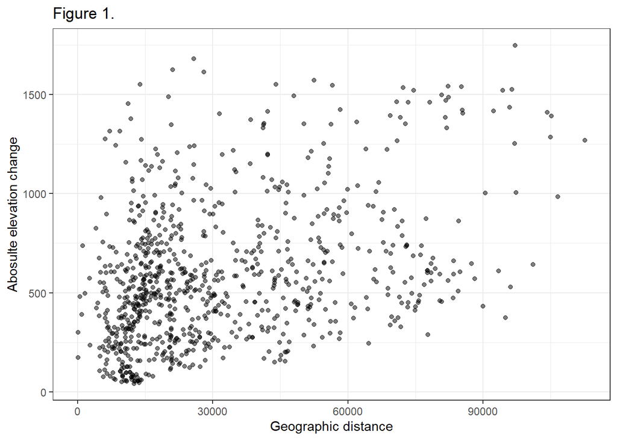

## Classification of behaviors along distance/elevation spectrum

However, we understand that there can be a need for labeling of distinct strategies. Accordingly, we classified migratory behaviors using K-means with three clusters (see Appendix regarding cluster number choice; Lowrey et al 2020). We were not able to distinguish between residents and short distance migrants. Though, there were distinct elevational and long distance migrants.

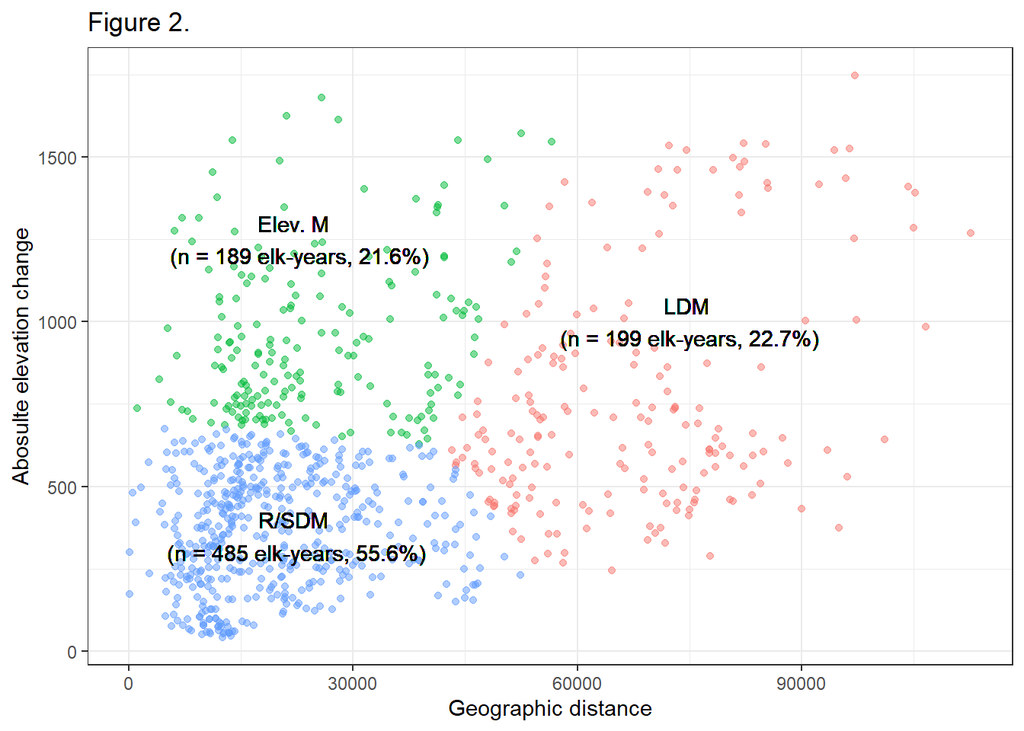

# Multiyear movements

## Plasitcity from one year to the next

### Within distance/elevation spectrum

The red dots represent the location in the distance/elevation spectrum in the first year of record, while the blue dots represent the location in the second year. The arrow indicates the direction of change.

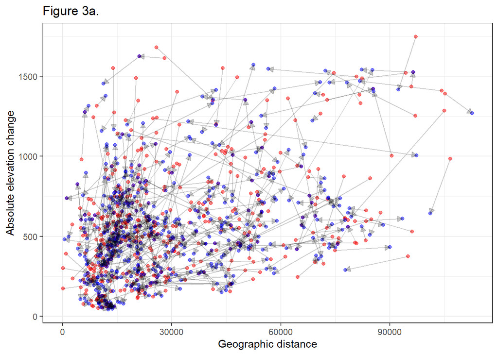

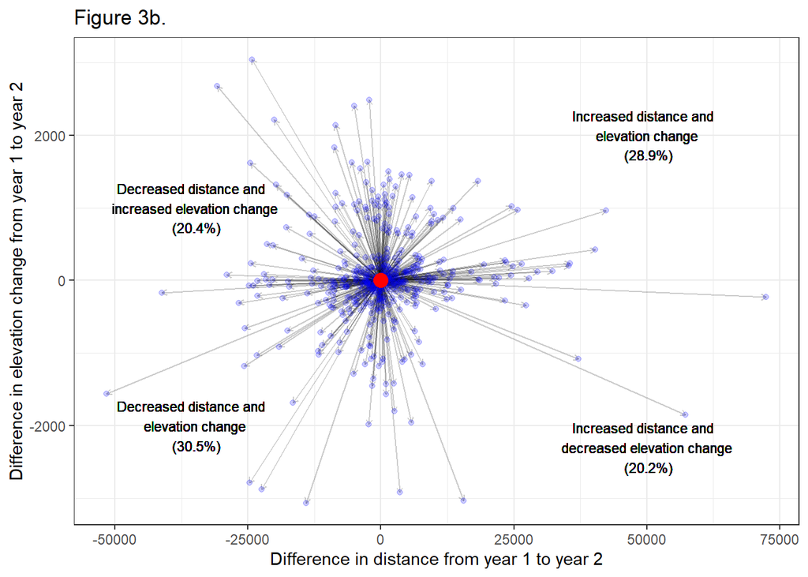

### And in classified behaviors

The left plot shows the all the classified strategies, with arrows indicating strategy from one year to the next, and dark arrows representing a change in stratgy. The right hand plot focus on the changes in strategy, of which there were 102 (20.6% overall, 21.5% yearly, SD = 7.4%).

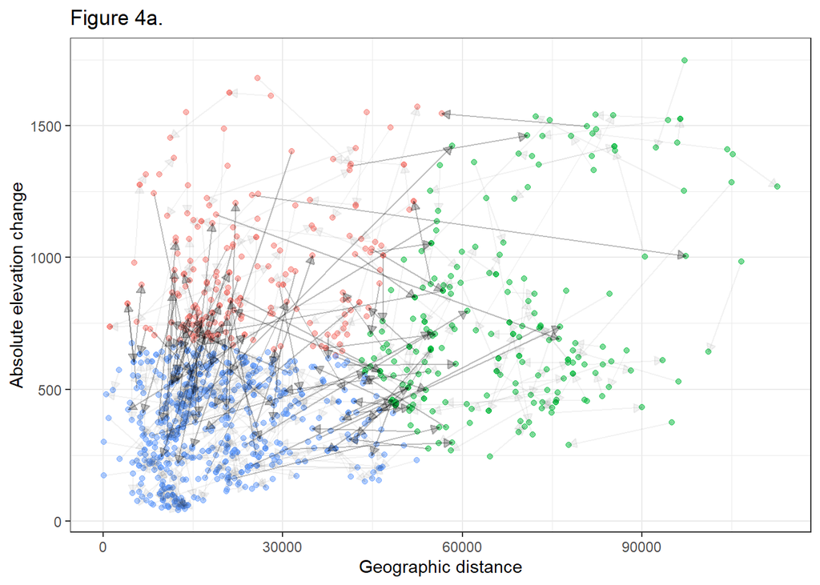

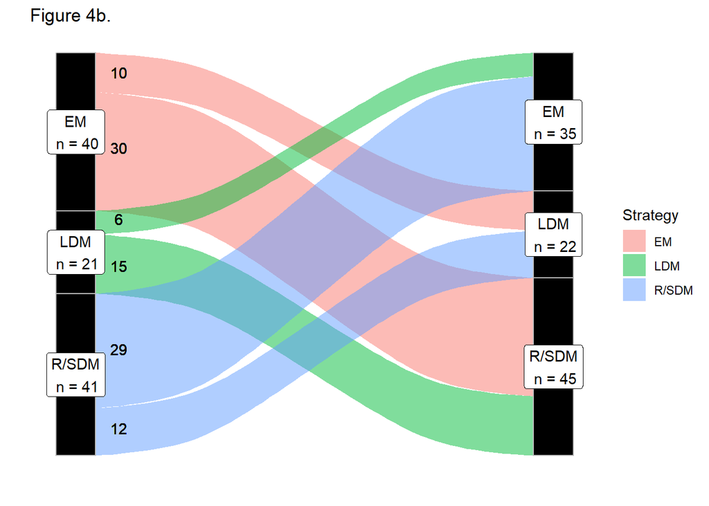

| years | strategy | from | to | balance |
| --- | --- | --- | --- | --- |
| 2006-2007 | EM | 4 | 4 | 0 |
| 2006-2007 | LDM | 2 | 4 | 2 |
| 2006-2007 | R/SDM | 9 | 7 | -2 |
| 2007-2008 | EM | 7 | 6 | -1 |
| 2007-2008 | LDM | 5 | 6 | 1 |
| 2007-2008 | R/SDM | 13 | 13 | 0 |
| 2008-2009 | EM | 8 | 9 | 1 |
| 2008-2009 | LDM | 7 | 5 | -2 |
| 2008-2009 | R/SDM | 33 | 34 | 1 |
| 2009-2010 | LDM | 2 | 3 | 1 |
| 2009-2010 | R/SDM | 46 | 47 | 1 |
| 2010-2011 | EM | 4 | 3 | -1 |
| 2010-2011 | LDM | 7 | 6 | -1 |
| 2010-2011 | R/SDM | 22 | 24 | 2 |
| 2011-2012 | LDM | 17 | 14 | -3 |
| 2011-2012 | R/SDM | 12 | 15 | 3 |
| 2012-2013 | EM | 4 | 4 | 0 |
| 2012-2013 | LDM | 8 | 8 | 0 |
| 2012-2013 | R/SDM | 28 | 28 | 0 |
| 2013-2014 | LDM | 8 | 7 | -1 |
| 2013-2014 | R/SDM | 8 | 9 | 1 |
| 2014-2015 | EM | 12 | 13 | 1 |
| 2014-2015 | LDM | 20 | 17 | -3 |
| 2014-2015 | R/SDM | 29 | 31 | 2 |
| 2015-2016 | EM | 22 | 21 | -1 |
| 2015-2016 | LDM | 8 | 11 | 3 |
| 2015-2016 | R/SDM | 27 | 25 | -2 |
| 2016-2017 | EM | 15 | 11 | -4 |
| 2016-2017 | LDM | 4 | 6 | 2 |
| 2016-2017 | R/SDM | 13 | 15 | 2 |
| 2017-2018 | EM | 6 | 9 | 3 |
| 2017-2018 | LDM | 1 | 1 | 0 |
| 2017-2018 | R/SDM | 9 | 6 | -3 |
| 2018-2019 | EM | 9 | 9 | 0 |
| 2018-2019 | LDM | 4 | 5 | 1 |
| 2018-2019 | R/SDM | 21 | 20 | -1 |
| 2019-2020 | EM | 16 | 15 | -1 |
| 2019-2020 | LDM | 18 | 19 | 1 |
| 2019-2020 | R/SDM | 6 | 6 | 0 |

## What contributes to increased or decreased plasticty?

We modeled the magnitude of shift in the location from one year to the next (ie, the length of the arrows in Figures 3a and 3b). This metric is indicative of how big of a change an elk made from one year to the next, but not of the direction of that change.

Below are all the models within delta AIC of 2. Herd diversity and proportion of developed land appear in all models.

Taking these 5 models, we identified the model with the lowest RMSE (via LOOCV).

| vars | interaction | AIC | RMSE | MAE | Rsquared |
| --- | --- | --- | --- | --- | --- |
| herdDiversity, migDev | TRUE | 10329.60 | 8198.829 | 5554.683 | 0.1027574 |
| herdDiversity, propCrop , migDev | FALSE | 10330.70 | 8219.832 | 5519.989 | 0.0983018 |
| herdDiversity, propCrop , migDev | TRUE | 10331.38 | 8199.441 | 5514.179 | 0.1031314 |
| herdDiversity, migDev , winterDev | TRUE | 10330.74 | 8194.326 | 5554.869 | 0.1042780 |
| herdDiversity, migDev , feedAccess | TRUE | 10330.74 | 8185.212 | 5513.556 | 0.1060187 |

## What contributes to the directionality of plasticity?

We modeled the directionality of plasticity via the quadrant (in Figure 3b) it fell in. For example, class 1 would indicate both an increase geographical distance and elevation change. The top models for each class can be found below.

[output not shown]

| target | vars | interaction | AIC | within2 | accuracy |
| --- | --- | --- | --- | --- | --- |
| 1 | propCrop, maxSnow | FALSE | 580.3935 | TRUE | 0.7191919 |
| 1 | herdDiversity, propCrop , propPrivate , maxSnow | FALSE | 579.6153 | TRUE | 0.7171717 |
| 1 | herdDiversity, propCrop , maxSnow | FALSE | 578.7076 | TRUE | 0.7151515 |
| 1 | propCrop, meanDFP , maxSnow | FALSE | 579.9713 | TRUE | 0.7151515 |
| 1 | herdDiversity, propCrop , migDev , maxSnow | FALSE | 580.3317 | TRUE | 0.7151515 |
| 1 | herdDiversity, propCrop , feedAccess , maxSnow | FALSE | 580.5834 | TRUE | 0.7151515 |
| 1 | herdDiversity, propCrop , winterDev , maxSnow | FALSE | 580.5463 | TRUE | 0.7131313 |
| 1 | herdDiversity, propCrop , meanDFP , propPrivate , maxSnow | FALSE | 580.5920 | TRUE | 0.7111111 |
| 1 | herdDiversity, propCrop , meanDFP , maxSnow | FALSE | 579.1468 | TRUE | 0.7090909 |
| 2 | herdDiversity, propCrop | TRUE | 490.4242 | TRUE | 0.7979798 |
| 2 | herdDiversity, propCrop , propPrivate | TRUE | 489.8015 | TRUE | 0.7919192 |
| 3 | herdDiversity, propCrop , maxSnow | TRUE | 600.5413 | TRUE | 0.6989899 |
| 3 | herdDiversity, propCrop | TRUE | 601.0224 | TRUE | 0.6929293 |
| 3 | herdDiversity, propCrop , propPrivate | TRUE | 600.6280 | TRUE | 0.6888889 |
| 3 | herdDiversity, propCrop , propPrivate , maxSnow | TRUE | 601.3827 | TRUE | 0.6888889 |
| 3 | herdDiversity, propCrop , meanDFP | TRUE | 601.0432 | TRUE | 0.6828283 |
| 4 | herdDiversity | FALSE | 496.1558 | TRUE | 0.7959596 |
| 4 | herdDiversity, propCrop | FALSE | 497.9821 | TRUE | 0.7959596 |
| 4 | herdDiversity, migDev | FALSE | 497.3386 | TRUE | 0.7959596 |
| 4 | herdDiversity, winterDev | FALSE | 498.0923 | TRUE | 0.7959596 |
| 4 | herdDiversity, feedAccess | FALSE | 498.1088 | TRUE | 0.7959596 |
| 4 | herdDiversity, meanDFP | FALSE | 496.3143 | TRUE | 0.7959596 |
| 4 | herdDiversity, meanDFP | TRUE | 496.9032 | TRUE | 0.7959596 |
| 4 | herdDiversity, propPrivate | FALSE | 497.6309 | TRUE | 0.7959596 |
| 4 | herdDiversity, maxSnow | FALSE | 498.0085 | TRUE | 0.7959596 |
| 4 | herdDiversity, propCrop , meanDFP | FALSE | 498.0148 | TRUE | 0.7959596 |
| 4 | herdDiversity, propCrop , maxSnow | TRUE | 497.4318 | TRUE | 0.7959596 |
| 4 | herdDiversity, migDev , meanDFP | FALSE | 497.0597 | TRUE | 0.7959596 |
| 4 | herdDiversity, propCrop , winterDev , maxSnow | TRUE | 497.3132 | TRUE | 0.7959596 |
| 4 | herdDiversity, propCrop , winterDev , propPrivate , maxSnow | TRUE | 496.6565 | TRUE | 0.7898990 |

## Appendix

We performed k-means on scaled and centered data. We evaluted the plots to identify k, such that the within group sum of squared Euclidean distances was minimized, but the between group sum of squared distances was maximized. Between and within group sum of squares intersected between 2 and 3, indicating that the ideal number of clusters to balance the two was either two or three.

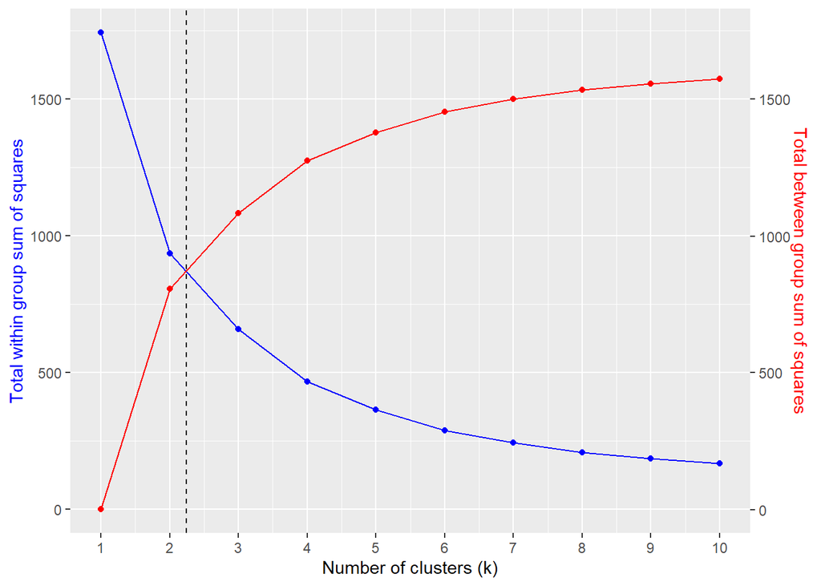

Below are cluster plots with 2 and 3 clusters. Using three clusters provided a more ecologically meaningful grouping.

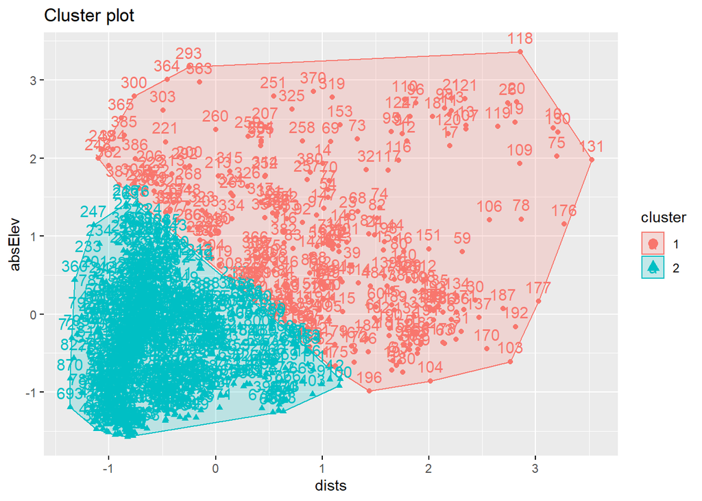

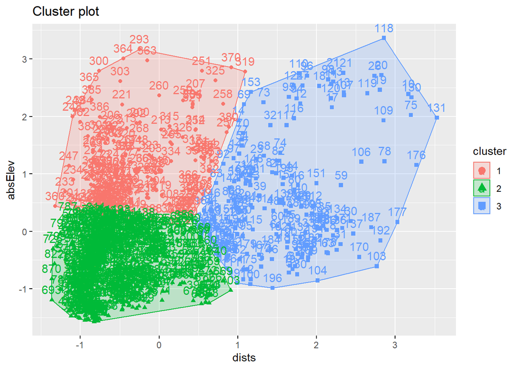